# Diabetic Patients Readmission Analysis

```python
import pandas as pd
import numpy as np
```

```python
readmission_df = pd.read_csv ("C:/Users/Dell/OneDrive/Desktop/diabetes_readmission/diabetic_data.csv")
```

```python
readmission_df
```

|  | encounter_id | patient_nbr | race | gender | age | weight | admission_type_id | discharge_disposition_id | admission_source_id | time_in_hospital | ... | citoglipton | insulin | glyburide-metformin | glipizide-metformin | glimepiride-pioglitazone | metformin-rosiglitazone | metformin-pioglitazone | change | diabetesMed | readmitted |
| --- | --- | --- | --- | --- | --- | --- | --- | --- | --- | --- | --- | --- | --- | --- | --- | --- | --- | --- | --- | --- | --- |
| 0 | 2278392 | 8222157 | Caucasian | Female | [0-10) | ? | 6 | 25 | 1 | 1 | ... | No | No | No | No | No | No | No | No | No | NO |
| 1 | 149190 | 55629189 | Caucasian | Female | [10-20) | ? | 1 | 1 | 7 | 3 | ... | No | Up | No | No | No | No | No | Ch | Yes | >30 |
| 2 | 64410 | 86047875 | AfricanAmerican | Female | [20-30) | ? | 1 | 1 | 7 | 2 | ... | No | No | No | No | No | No | No | No | Yes | NO |
| 3 | 500364 | 82442376 | Caucasian | Male | [30-40) | ? | 1 | 1 | 7 | 2 | ... | No | Up | No | No | No | No | No | Ch | Yes | NO |
| 4 | 16680 | 42519267 | Caucasian | Male | [40-50) | ? | 1 | 1 | 7 | 1 | ... | No | Steady | No | No | No | No | No | Ch | Yes | NO |
| ... | ... | ... | ... | ... | ... | ... | ... | ... | ... | ... | ... | ... | ... | ... | ... | ... | ... | ... | ... | ... | ... |
| 101761 | 443847548 | 100162476 | AfricanAmerican | Male | [70-80) | ? | 3 | 3 | 2 | 3 | ... | No | Steady | No | No | No | No | No | Ch | Yes | >30 |
| 101762 | 443847782 | 74694222 | AfricanAmerican | Female | [80-90) | ? | 4 | 4 | 1 | 5 | ... | No | No | No | No | No | No | No | No | Yes | NO |
| 101763 | 443854148 | 41088789 | Caucasian | Male | [70-80) | ? | 4 | 1 | 2 | 1 | ... | No | No | No | No | No | No | No | Ch | Yes | NO |
| 101764 | 443857166 | 31693671 | Caucasian | Female | [80-90) | ? | 4 | 3 | 1 | 10 | ... | No | No | No | No | No | No | No | Ch | Yes | NO |
| 101765 | 443867222 | 175429310 | Caucasian | Male | [70-80) | ? | 2 | 1 | 2 | 6 | ... | No | Down | No | No | No | No | No | No | No | NO |

101766 rows × 50 columns

```python
#Dataset size
readmission_df.shape
```

```
(101766, 50)
```

## Descriptive analysis

```python
readmission_df.describe()
```

|  | encounter_id | patient_nbr | admission_type_id | discharge_disposition_id | admission_source_id | time_in_hospital | num_lab_procedures | num_procedures | num_medications | number_outpatient | number_emergency | number_inpatient | number_diagnoses |
| --- | --- | --- | --- | --- | --- | --- | --- | --- | --- | --- | --- | --- | --- |
| count | 1.017660e+05 | 1.017660e+05 | 101766.000000 | 101766.000000 | 101766.000000 | 101766.000000 | 101766.000000 | 101766.000000 | 101766.000000 | 101766.000000 | 101766.000000 | 101766.000000 | 101766.000000 |
| mean | 1.652016e+08 | 5.433040e+07 | 2.675904 | 4.388362 | 4.372443 | 4.589696 | 34.047383 | 1.456577 | 16.560492 | 0.369357 | 0.212232 | 0.635566 | 7.422607 |
| std | 1.026403e+08 | 3.869636e+07 | 1.530799 | 6.013795 | 4.687549 | 3.160314 | 22.386944 | 1.792201 | 9.105980 | 1.267265 | 0.917842 | 1.262863 | 1.933600 |
| min | 1.252200e+04 | 1.350000e+02 | 1.000000 | 1.000000 | 1.000000 | 1.000000 | 1.000000 | 0.000000 | 1.000000 | 0.000000 | 0.000000 | 0.000000 | 1.000000 |
| 25% | 8.496119e+07 | 2.341322e+07 | 1.000000 | 1.000000 | 1.000000 | 2.000000 | 16.000000 | 0.000000 | 10.000000 | 0.000000 | 0.000000 | 0.000000 | 6.000000 |
| 50% | 1.523890e+08 | 4.550514e+07 | 3.000000 | 1.000000 | 2.000000 | 4.000000 | 30.000000 | 1.000000 | 15.000000 | 0.000000 | 0.000000 | 0.000000 | 8.000000 |
| 75% | 2.302709e+08 | 8.754595e+07 | 4.000000 | 6.000000 | 7.000000 | 6.000000 | 49.000000 | 2.000000 | 20.000000 | 0.000000 | 0.000000 | 1.000000 | 9.000000 |
| max | 4.438672e+08 | 1.895026e+08 | 8.000000 | 28.000000 | 25.000000 | 14.000000 | 129.000000 | 6.000000 | 81.000000 | 42.000000 | 76.000000 | 21.000000 | 16.000000 |

```python
readmission_df.info()
```

```
<class 'pandas.core.frame.DataFrame'>
RangeIndex: 101766 entries, 0 to 101765
Data columns (total 50 columns):
 #   Column                    Non-Null Count   Dtype
---  ------                    --------------   -----
 0   encounter_id              101766 non-null  int64
 1   patient_nbr               101766 non-null  int64
 2   race                      101766 non-null  object
 3   gender                    101766 non-null  object
 4   age                       101766 non-null  object
 5   weight                    101766 non-null  object
 6   admission_type_id         101766 non-null  int64
 7   discharge_disposition_id  101766 non-null  int64
 8   admission_source_id       101766 non-null  int64
 9   time_in_hospital          101766 non-null  int64
```

[output cut: 42 more lines]

```python
readmission_df.isna().sum()
```

```
encounter_id                    0
patient_nbr                     0
race                            0
gender                          0
age                             0
weight                          0
admission_type_id               0
discharge_disposition_id        0
admission_source_id             0
time_in_hospital                0
payer_code                      0
medical_specialty               0
num_lab_procedures              0
num_procedures                  0
num_medications                 0
number_outpatient               0
number_emergency                0
number_inpatient                0
diag_1                          0
diag_2                          0
diag_3                          0
number_diagnoses                0
max_glu_serum               96420
A1Cresult                   84748
metformin                       0
repaglinide                     0
nateglinide                     0
chlorpropamide                  0
glimepiride                     0
acetohexamide                   0
glipizide                       0
glyburide                       0
tolbutamide                     0
pioglitazone                    0
rosiglitazone                   0
acarbose                        0
miglitol                        0
troglitazone                    0
tolazamide                      0
examide                         0
citoglipton                     0
insulin                         0
glyburide-metformin             0
glipizide-metformin             0
glimepiride-pioglitazone        0
metformin-rosiglitazone         0
metformin-pioglitazone          0
change                          0
diabetesMed                     0
readmitted                      0
dtype: int64
```

### Missing values

From above we noticed a significant number of records missing. Considering our dataset has 101,766 records, there are glucose serum test has 96420 (95%) and AIC result has 84748(83%) missing values. Dropping these columns could lead to significant loss of data. Instead of filling in missing lab values, glucose results were grouped into clinical risk categories and non-tested cases were analyzed separately. This allows decision-makers to understand both glycemic control and care intensity, rather than relying on imputed or misleading values.

```python
readmission_df['max_glu_serum_clean'] = readmission_df['max_glu_serum'].fillna('Not Measured')
readmission_df['a1cresult_clean'] = readmission_df['A1Cresult'].fillna('Not Measured')
```

```python
readmission_df.isna().sum()
```

```
encounter_id                    0
patient_nbr                     0
race                            0
gender                          0
age                             0
weight                          0
admission_type_id               0
discharge_disposition_id        0
admission_source_id             0
time_in_hospital                0
payer_code                      0
medical_specialty               0
num_lab_procedures              0
num_procedures                  0
num_medications                 0
number_outpatient               0
number_emergency                0
number_inpatient                0
diag_1                          0
diag_2                          0
diag_3                          0
number_diagnoses                0
max_glu_serum               96420
A1Cresult                   84748
metformin                       0
repaglinide                     0
nateglinide                     0
chlorpropamide                  0
glimepiride                     0
acetohexamide                   0
glipizide                       0
glyburide                       0
tolbutamide                     0
pioglitazone                    0
rosiglitazone                   0
acarbose                        0
miglitol                        0
troglitazone                    0
tolazamide                      0
examide                         0
citoglipton                     0
insulin                         0
glyburide-metformin             0
glipizide-metformin             0
glimepiride-pioglitazone        0
metformin-rosiglitazone         0
metformin-pioglitazone          0
change                          0
diabetesMed                     0
readmitted                      0
max_glu_serum_clean             0
a1cresult_clean                 0
dtype: int64
```

```python
glu_map = {
    'Norm': 'Normal',
    '>200': 'High',
    '>300': 'Very High'
}

a1c_map = {
    'Norm': 'Normal',
    '>7': 'Elevated',
    '>8': 'Poor Control'
}

readmission_df['glu_risk'] = readmission_df['max_glu_serum'].map(glu_map).fillna('Not Measured')
readmission_df['a1c_risk'] = readmission_df['A1Cresult'].map(a1c_map).fillna('Not Measured')

readmission_df['glu_tested'] = readmission_df['max_glu_serum'].notna().map({True: 'Yes', False: 'No'})
readmission_df['a1c_tested'] = readmission_df['A1Cresult'].notna().map({True: 'Yes', False: 'No'})
```

# Appropriate datatypes

IDs → text (categorical)  
Codes → categorical  
Counts → whole numbers  
Risk / status → categorical  
Outcome → categorical  
Power BI works best when meaning ≠ number is treated as category, not numeric.

- We didn’t group all categorical columns together because they mean different things, even if they share the same datatype. Theefore the codes to change datatypes dont reflect inconsistency but clarity for later mapping for some categories.

```python
readmission_df.info()
```

```
<class 'pandas.core.frame.DataFrame'>
RangeIndex: 101766 entries, 0 to 101765
Data columns (total 56 columns):
 #   Column                    Non-Null Count   Dtype
---  ------                    --------------   -----
 0   encounter_id              101766 non-null  int64
 1   patient_nbr               101766 non-null  int64
 2   race                      101766 non-null  object
 3   gender                    101766 non-null  object
 4   age                       101766 non-null  object
 5   weight                    101766 non-null  object
 6   admission_type_id         101766 non-null  int64
 7   discharge_disposition_id  101766 non-null  int64
 8   admission_source_id       101766 non-null  int64
 9   time_in_hospital          101766 non-null  int64
```

[output cut: 48 more lines]

```python
#
readmission_df['encounter_id'] = readmission_df['encounter_id'].astype(str)
readmission_df['patient_nbr'] = readmission_df['patient_nbr'].astype(str)
```

```python
# All coded categorical datatypes
cat_cols = [
    'admission_type_id',
    'discharge_disposition_id',
    'admission_source_id'
]

for col in cat_cols:
    readmission_df[col] = readmission_df[col].astype('category')
```

```python
# Dataypes of clear , fixed catogaries
readmission_df[['age','gender','race']] = readmission_df[['age','gender','race']].astype('category')
```

```python
# dataypes of number columns
# these values will support aggregation, averages , and KPIs
num_cols = [
    'time_in_hospital','num_lab_procedures','num_procedures',
    'num_medications','number_outpatient','number_emergency',
    'number_inpatient','number_diagnoses'
]

readmission_df[num_cols] = readmission_df[num_cols].astype(int)
```

```python
# clinical status labels Glucose and AIc Risk
readmission_df[['glu_risk','a1c_risk','glu_tested','a1c_tested']] = (
    readmission_df[['glu_risk','a1c_risk','glu_tested','a1c_tested']]
    .astype('category')
)
```

```python
# Medication and treatment

readmission_df[['change','diabetesmed']] = readmission_df[['change','diabetesMed']].astype('category')
```

```python
# Target Variable
# generating target variable as a flagged variable
readmission_df['readmitted_flag'] =readmission_df['readmitted'].map({
    'NO': 0,
    '<30': 1,
    '>30': 1
})

readmission_df['readmitted_flag'] = readmission_df['readmitted_flag'].astype('category')

#Readmission status was retained as a categorical variable for interpretability, with an additional binary flag engineered to support modeling and KPI calculation.
```

# Finalised dataset

The cleaneed dataset columns selected for anlaysis.

The final dataset was curated to retain clinically meaningful, low-noise features related to patient demographics, admission context, prior utilization, diabetes management, and readmission outcomes. High-missingness and high-cardinality variables were excluded to optimize interpretability and Power BI performance.

The following coluumns were dropped :

1. weights - >95% missing
2. payer_code - low relevance
3. medical speciality - High cardinality
4. diag 1/2/3 - increases granularity in BI
5. Raw lab - replaced by risk flag
6. medications - less relevance to whether diabetes med was changed or given

```python
# selecting coulumns
final_cols = [
    # Identifiers
    'encounter_id',
    'patient_nbr',

    # Demographics
    'age',
    'gender',
    'race',

    # Admission & discharge context
    'admission_type_id',
    'admission_source_id',
    'discharge_disposition_id',

    # Hospital utilization & clinical intensity
    'time_in_hospital',
    'num_lab_procedures',
    'num_procedures',
    'num_medications',
    'number_diagnoses',

    # Prior utilization
    'number_outpatient',
    'number_emergency',
    'number_inpatient',

    # Diabetes & labs (engineered)
    'glu_risk',
    'a1c_risk',
    'glu_tested',
    'a1c_tested',
    'diabetesmed',
    'change',

    # Outcome
    'readmitted',
    'readmitted_flag'
]

readmission_df = readmission_df[final_cols]
readmission_df = readmission_df[final_cols].copy() #An explicit dataframe copy was created after feature selection to avoid chained assignment while preserving all previously defined datatypes.
```

```python
readmission_df.head()
```

|  | encounter_id | patient_nbr | age | gender | race | admission_type_id | admission_source_id | discharge_disposition_id | time_in_hospital | num_lab_procedures | ... | number_emergency | number_inpatient | glu_risk | a1c_risk | glu_tested | a1c_tested | diabetesmed | change | readmitted | readmitted_flag |
| --- | --- | --- | --- | --- | --- | --- | --- | --- | --- | --- | --- | --- | --- | --- | --- | --- | --- | --- | --- | --- | --- |
| 0 | 2278392 | 8222157 | [0-10) | Female | Caucasian | 6 | 1 | 25 | 1 | 41 | ... | 0 | 0 | Not Measured | Not Measured | No | No | No | No | NO | 0 |
| 1 | 149190 | 55629189 | [10-20) | Female | Caucasian | 1 | 7 | 1 | 3 | 59 | ... | 0 | 0 | Not Measured | Not Measured | No | No | Yes | Ch | >30 | 1 |
| 2 | 64410 | 86047875 | [20-30) | Female | AfricanAmerican | 1 | 7 | 1 | 2 | 11 | ... | 0 | 1 | Not Measured | Not Measured | No | No | Yes | No | NO | 0 |
| 3 | 500364 | 82442376 | [30-40) | Male | Caucasian | 1 | 7 | 1 | 2 | 44 | ... | 0 | 0 | Not Measured | Not Measured | No | No | Yes | Ch | NO | 0 |
| 4 | 16680 | 42519267 | [40-50) | Male | Caucasian | 1 | 7 | 1 | 1 | 51 | ... | 0 | 0 | Not Measured | Not Measured | No | No | Yes | Ch | NO | 0 |

5 rows × 24 columns

```python
readmission_df.info()
```

```
<class 'pandas.core.frame.DataFrame'>
RangeIndex: 101766 entries, 0 to 101765
Data columns (total 24 columns):
 #   Column                    Non-Null Count   Dtype
---  ------                    --------------   -----
 0   encounter_id              101766 non-null  object
 1   patient_nbr               101766 non-null  object
 2   age                       101766 non-null  category
 3   gender                    101766 non-null  category
 4   race                      101766 non-null  category
 5   admission_type_id         101766 non-null  category
 6   admission_source_id       101766 non-null  category
 7   discharge_disposition_id  101766 non-null  category
 8   time_in_hospital          101766 non-null  int32
 9   num_lab_procedures        101766 non-null  int32
```

[output cut: 16 more lines]

```python
# changing binary columns to 0 /1 for KPi
# Convert Yes/No flags to binary
flag_cols = ['glu_tested', 'a1c_tested', 'diabetesmed', 'change']

for col in flag_cols:
    readmission_df[col + '_bin'] = readmission_df[col].map({'Yes': 1, 'No': 0, 'Ch': 0})
```

```python
# making gender binary as well
# 1 = Male, 0 = Female
readmission_df['gender_binary'] = readmission_df['gender'].map({'Male':1, 'Female':0})
```

```python
readmission_df['gender_binary'] = readmission_df['gender'].map({'Male':1, 'Female':0})
```

```python
readmission_df
```

|  | encounter_id | patient_nbr | age | gender | race | admission_type_id | admission_source_id | discharge_disposition_id | time_in_hospital | num_lab_procedures | ... | a1c_tested | diabetesmed | change | readmitted | readmitted_flag | glu_tested_bin | a1c_tested_bin | diabetesmed_bin | change_bin | gender_binary |
| --- | --- | --- | --- | --- | --- | --- | --- | --- | --- | --- | --- | --- | --- | --- | --- | --- | --- | --- | --- | --- | --- |
| 0 | 2278392 | 8222157 | [0-10) | Female | Caucasian | 6 | 1 | 25 | 1 | 41 | ... | No | No | No | NO | 0 | 0 | 0 | 0 | 0 | 0.0 |
| 1 | 149190 | 55629189 | [10-20) | Female | Caucasian | 1 | 7 | 1 | 3 | 59 | ... | No | Yes | Ch | >30 | 1 | 0 | 0 | 1 | 0 | 0.0 |
| 2 | 64410 | 86047875 | [20-30) | Female | AfricanAmerican | 1 | 7 | 1 | 2 | 11 | ... | No | Yes | No | NO | 0 | 0 | 0 | 1 | 0 | 0.0 |
| 3 | 500364 | 82442376 | [30-40) | Male | Caucasian | 1 | 7 | 1 | 2 | 44 | ... | No | Yes | Ch | NO | 0 | 0 | 0 | 1 | 0 | 1.0 |
| 4 | 16680 | 42519267 | [40-50) | Male | Caucasian | 1 | 7 | 1 | 1 | 51 | ... | No | Yes | Ch | NO | 0 | 0 | 0 | 1 | 0 | 1.0 |
| ... | ... | ... | ... | ... | ... | ... | ... | ... | ... | ... | ... | ... | ... | ... | ... | ... | ... | ... | ... | ... | ... |
| 101761 | 443847548 | 100162476 | [70-80) | Male | AfricanAmerican | 3 | 2 | 3 | 3 | 14 | ... | Yes | Yes | Ch | >30 | 1 | 0 | 1 | 1 | 0 | 1.0 |
| 101762 | 443847782 | 74694222 | [80-90) | Female | AfricanAmerican | 4 | 1 | 4 | 5 | 20 | ... | No | Yes | No | NO | 0 | 0 | 0 | 1 | 0 | 0.0 |
| 101763 | 443854148 | 41088789 | [70-80) | Male | Caucasian | 4 | 2 | 1 | 1 | 29 | ... | No | Yes | Ch | NO | 0 | 0 | 0 | 1 | 0 | 1.0 |
| 101764 | 443857166 | 31693671 | [80-90) | Female | Caucasian | 4 | 1 | 3 | 10 | 17 | ... | No | Yes | Ch | NO | 0 | 0 | 0 | 1 | 0 | 0.0 |
| 101765 | 443867222 | 175429310 | [70-80) | Male | Caucasian | 2 | 2 | 1 | 6 | 29 | ... | No | No | No | NO | 0 | 0 | 0 | 0 | 0 | 1.0 |

101766 rows × 29 columns

```python
readmission_df.info()
```

```
<class 'pandas.core.frame.DataFrame'>
RangeIndex: 101766 entries, 0 to 101765
Data columns (total 29 columns):
 #   Column                    Non-Null Count   Dtype
---  ------                    --------------   -----
 0   encounter_id              101766 non-null  object
 1   patient_nbr               101766 non-null  object
 2   age                       101766 non-null  category
 3   gender                    101766 non-null  category
 4   race                      101766 non-null  category
 5   admission_type_id         101766 non-null  category
 6   admission_source_id       101766 non-null  category
 7   discharge_disposition_id  101766 non-null  category
 8   time_in_hospital          101766 non-null  int32
 9   num_lab_procedures        101766 non-null  int32
```

[output cut: 21 more lines]

```python
readmission_df.isnull().sum()
```

```
encounter_id                0
patient_nbr                 0
age                         0
gender                      0
race                        0
admission_type_id           0
admission_source_id         0
discharge_disposition_id    0
time_in_hospital            0
num_lab_procedures          0
num_procedures              0
num_medications             0
number_diagnoses            0
number_outpatient           0
number_emergency            0
number_inpatient            0
glu_risk                    0
a1c_risk                    0
glu_tested                  0
a1c_tested                  0
diabetesmed                 0
change                      0
readmitted                  0
readmitted_flag             0
glu_tested_bin              0
a1c_tested_bin              0
diabetesmed_bin             0
change_bin                  0
gender_binary               3
dtype: int64
```

```python
# filling gender_binary missing values as females
readmission_df['gender_binary'] = readmission_df['gender_binary'].fillna(0).astype(int)
readmission_df['gender_binary'].unique()
readmission_df.info()
```

```
<class 'pandas.core.frame.DataFrame'>
RangeIndex: 101766 entries, 0 to 101765
Data columns (total 29 columns):
 #   Column                    Non-Null Count   Dtype
---  ------                    --------------   -----
 0   encounter_id              101766 non-null  object
 1   patient_nbr               101766 non-null  object
 2   age                       101766 non-null  category
 3   gender                    101766 non-null  category
 4   race                      101766 non-null  category
 5   admission_type_id         101766 non-null  category
 6   admission_source_id       101766 non-null  category
 7   discharge_disposition_id  101766 non-null  category
 8   time_in_hospital          101766 non-null  int32
 9   num_lab_procedures        101766 non-null  int32
```

[output cut: 21 more lines]

```python
binary_cols = ['glu_tested_bin', 'a1c_tested_bin', 'diabetesmed_bin', 'change_bin', 'readmitted_flag']
readmission_df[binary_cols] = readmission_df[binary_cols].astype(int)
```

```python
readmission_df
```

|  | encounter_id | patient_nbr | age | gender | race | admission_type_id | admission_source_id | discharge_disposition_id | time_in_hospital | num_lab_procedures | ... | a1c_tested | diabetesmed | change | readmitted | readmitted_flag | glu_tested_bin | a1c_tested_bin | diabetesmed_bin | change_bin | gender_binary |
| --- | --- | --- | --- | --- | --- | --- | --- | --- | --- | --- | --- | --- | --- | --- | --- | --- | --- | --- | --- | --- | --- |
| 0 | 2278392 | 8222157 | [0-10) | Female | Caucasian | 6 | 1 | 25 | 1 | 41 | ... | No | No | No | NO | 0 | 0 | 0 | 0 | 0 | 0 |
| 1 | 149190 | 55629189 | [10-20) | Female | Caucasian | 1 | 7 | 1 | 3 | 59 | ... | No | Yes | Ch | >30 | 1 | 0 | 0 | 1 | 0 | 0 |
| 2 | 64410 | 86047875 | [20-30) | Female | AfricanAmerican | 1 | 7 | 1 | 2 | 11 | ... | No | Yes | No | NO | 0 | 0 | 0 | 1 | 0 | 0 |
| 3 | 500364 | 82442376 | [30-40) | Male | Caucasian | 1 | 7 | 1 | 2 | 44 | ... | No | Yes | Ch | NO | 0 | 0 | 0 | 1 | 0 | 1 |
| 4 | 16680 | 42519267 | [40-50) | Male | Caucasian | 1 | 7 | 1 | 1 | 51 | ... | No | Yes | Ch | NO | 0 | 0 | 0 | 1 | 0 | 1 |
| ... | ... | ... | ... | ... | ... | ... | ... | ... | ... | ... | ... | ... | ... | ... | ... | ... | ... | ... | ... | ... | ... |
| 101761 | 443847548 | 100162476 | [70-80) | Male | AfricanAmerican | 3 | 2 | 3 | 3 | 14 | ... | Yes | Yes | Ch | >30 | 1 | 0 | 1 | 1 | 0 | 1 |
| 101762 | 443847782 | 74694222 | [80-90) | Female | AfricanAmerican | 4 | 1 | 4 | 5 | 20 | ... | No | Yes | No | NO | 0 | 0 | 0 | 1 | 0 | 0 |
| 101763 | 443854148 | 41088789 | [70-80) | Male | Caucasian | 4 | 2 | 1 | 1 | 29 | ... | No | Yes | Ch | NO | 0 | 0 | 0 | 1 | 0 | 1 |
| 101764 | 443857166 | 31693671 | [80-90) | Female | Caucasian | 4 | 1 | 3 | 10 | 17 | ... | No | Yes | Ch | NO | 0 | 0 | 0 | 1 | 0 | 0 |
| 101765 | 443867222 | 175429310 | [70-80) | Male | Caucasian | 2 | 2 | 1 | 6 | 29 | ... | No | No | No | NO | 0 | 0 | 0 | 0 | 0 | 1 |

101766 rows × 29 columns

```python
#dropping uunnecessary columns
readmission_df.drop(columns=['glu_tested','a1c_tested','diabetesmed','change'], inplace=True)
```

```python
#renaming columns
readmission_df.rename(columns={
    'glu_tested_bin':'glu_tested',
    'a1c_tested_bin':'a1c_tested',
    'diabetesmed_bin':'diabetes_med',
    'change_bin':'med_change',
    'readmitted_flag':'readmitted_binary'
}, inplace=True)
```

```python
readmission_df
```

|  | encounter_id | patient_nbr | age | gender | race | admission_type_id | admission_source_id | discharge_disposition_id | time_in_hospital | num_lab_procedures | ... | number_inpatient | glu_risk | a1c_risk | readmitted | readmitted_binary | glu_tested | a1c_tested | diabetes_med | med_change | gender_binary |
| --- | --- | --- | --- | --- | --- | --- | --- | --- | --- | --- | --- | --- | --- | --- | --- | --- | --- | --- | --- | --- | --- |
| 0 | 2278392 | 8222157 | [0-10) | Female | Caucasian | 6 | 1 | 25 | 1 | 41 | ... | 0 | Not Measured | Not Measured | NO | 0 | 0 | 0 | 0 | 0 | 0 |
| 1 | 149190 | 55629189 | [10-20) | Female | Caucasian | 1 | 7 | 1 | 3 | 59 | ... | 0 | Not Measured | Not Measured | >30 | 1 | 0 | 0 | 1 | 0 | 0 |
| 2 | 64410 | 86047875 | [20-30) | Female | AfricanAmerican | 1 | 7 | 1 | 2 | 11 | ... | 1 | Not Measured | Not Measured | NO | 0 | 0 | 0 | 1 | 0 | 0 |
| 3 | 500364 | 82442376 | [30-40) | Male | Caucasian | 1 | 7 | 1 | 2 | 44 | ... | 0 | Not Measured | Not Measured | NO | 0 | 0 | 0 | 1 | 0 | 1 |
| 4 | 16680 | 42519267 | [40-50) | Male | Caucasian | 1 | 7 | 1 | 1 | 51 | ... | 0 | Not Measured | Not Measured | NO | 0 | 0 | 0 | 1 | 0 | 1 |
| ... | ... | ... | ... | ... | ... | ... | ... | ... | ... | ... | ... | ... | ... | ... | ... | ... | ... | ... | ... | ... | ... |
| 101761 | 443847548 | 100162476 | [70-80) | Male | AfricanAmerican | 3 | 2 | 3 | 3 | 14 | ... | 0 | Not Measured | Poor Control | >30 | 1 | 0 | 1 | 1 | 0 | 1 |
| 101762 | 443847782 | 74694222 | [80-90) | Female | AfricanAmerican | 4 | 1 | 4 | 5 | 20 | ... | 1 | Not Measured | Not Measured | NO | 0 | 0 | 0 | 1 | 0 | 0 |
| 101763 | 443854148 | 41088789 | [70-80) | Male | Caucasian | 4 | 2 | 1 | 1 | 29 | ... | 0 | Not Measured | Not Measured | NO | 0 | 0 | 0 | 1 | 0 | 1 |
| 101764 | 443857166 | 31693671 | [80-90) | Female | Caucasian | 4 | 1 | 3 | 10 | 17 | ... | 1 | Not Measured | Not Measured | NO | 0 | 0 | 0 | 1 | 0 | 0 |
| 101765 | 443867222 | 175429310 | [70-80) | Male | Caucasian | 2 | 2 | 1 | 6 | 29 | ... | 0 | Not Measured | Not Measured | NO | 0 | 0 | 0 | 0 | 0 | 1 |

101766 rows × 25 columns

```python
#FINAL CHECK
print(readmission_df.columns.tolist())
```

```
['encounter_id', 'patient_nbr', 'age', 'gender', 'race', 'admission_type_id', 'admission_source_id', 'discharge_disposition_id', 'time_in_hospital', 'num_lab_procedures', 'num_procedures', 'num_medications', 'number_diagnoses', 'number_outpatient', 'number_emergency', 'number_inpatient', 'glu_risk',…
```

```python
print(readmission_df.dtypes)
```

```
encounter_id                  object
patient_nbr                   object
age                         category
gender                      category
race                        category
admission_type_id           category
admission_source_id         category
discharge_disposition_id    category
time_in_hospital               int32
num_lab_procedures             int32
num_procedures                 int32
num_medications                int32
number_diagnoses               int32
number_outpatient              int32
number_emergency               int32
number_inpatient               int32
glu_risk                    category
a1c_risk                    category
readmitted                    object
readmitted_binary              int32
glu_tested                     int32
a1c_tested                     int32
diabetes_med                   int32
med_change                     int32
gender_binary                  int32
dtype: object
```

```python
print(readmission_df.isna().sum())
```

```
encounter_id                0
patient_nbr                 0
age                         0
gender                      0
race                        0
admission_type_id           0
admission_source_id         0
discharge_disposition_id    0
time_in_hospital            0
num_lab_procedures          0
num_procedures              0
num_medications             0
number_diagnoses            0
number_outpatient           0
number_emergency            0
number_inpatient            0
glu_risk                    0
a1c_risk                    0
readmitted                  0
readmitted_binary           0
glu_tested                  0
a1c_tested                  0
diabetes_med                0
med_change                  0
gender_binary               0
dtype: int64
```

```python
binary_cols = ['gender_binary','glu_tested','a1c_tested','diabetes_med','med_change','readmitted_binary']
for col in binary_cols:
    print(col, readmission_df[col].unique())
```

```
gender_binary [0 1]
glu_tested [0 1]
a1c_tested [0 1]
diabetes_med [0 1]
med_change [0]
readmitted_binary [0 1]
```

```python
readmission_df.shape  # rows, columns
```

```
(101766, 25)
```

```python
readmission_df.describe(include='all')  # summary statistics
```

|  | encounter_id | patient_nbr | age | gender | race | admission_type_id | admission_source_id | discharge_disposition_id | time_in_hospital | num_lab_procedures | ... | number_inpatient | glu_risk | a1c_risk | readmitted | readmitted_binary | glu_tested | a1c_tested | diabetes_med | med_change | gender_binary |
| --- | --- | --- | --- | --- | --- | --- | --- | --- | --- | --- | --- | --- | --- | --- | --- | --- | --- | --- | --- | --- | --- |
| count | 101766 | 101766 | 101766 | 101766 | 101766 | 101766.0 | 101766.0 | 101766.0 | 101766.000000 | 101766.000000 | ... | 101766.000000 | 101766 | 101766 | 101766 | 101766.000000 | 101766.000000 | 101766.000000 | 101766.000000 | 101766.0 | 101766.000000 |
| unique | 101766 | 71518 | 10 | 3 | 6 | 8.0 | 15.0 | 26.0 | NaN | NaN | ... | NaN | 4 | 4 | 3 | NaN | NaN | NaN | NaN | NaN | NaN |
| top | 2278392 | 88785891 | [70-80) | Female | Caucasian | 1.0 | 1.0 | 1.0 | NaN | NaN | ... | NaN | Not Measured | Not Measured | NO | NaN | NaN | NaN | NaN | NaN | NaN |
| freq | 1 | 40 | 26068 | 54708 | 76099 | 32219.0 | 36269.0 | 55967.0 | NaN | NaN | ... | NaN | 96420 | 84748 | 54864 | NaN | NaN | NaN | NaN | NaN | NaN |
| mean | NaN | NaN | NaN | NaN | NaN | NaN | NaN | NaN | 4.589696 | 34.047383 | ... | 0.635566 | NaN | NaN | NaN | 0.460881 | 0.052532 | 0.167227 | 0.714079 | 0.0 | 0.462384 |
| std | NaN | NaN | NaN | NaN | NaN | NaN | NaN | NaN | 3.160314 | 22.386944 | ... | 1.262863 | NaN | NaN | NaN | 0.498470 | 0.223099 | 0.373180 | 0.451854 | 0.0 | 0.498586 |
| min | NaN | NaN | NaN | NaN | NaN | NaN | NaN | NaN | 1.000000 | 1.000000 | ... | 0.000000 | NaN | NaN | NaN | 0.000000 | 0.000000 | 0.000000 | 0.000000 | 0.0 | 0.000000 |
| 25% | NaN | NaN | NaN | NaN | NaN | NaN | NaN | NaN | 2.000000 | 16.000000 | ... | 0.000000 | NaN | NaN | NaN | 0.000000 | 0.000000 | 0.000000 | 0.000000 | 0.0 | 0.000000 |
| 50% | NaN | NaN | NaN | NaN | NaN | NaN | NaN | NaN | 4.000000 | 30.000000 | ... | 0.000000 | NaN | NaN | NaN | 0.000000 | 0.000000 | 0.000000 | 1.000000 | 0.0 | 0.000000 |
| 75% | NaN | NaN | NaN | NaN | NaN | NaN | NaN | NaN | 6.000000 | 49.000000 | ... | 1.000000 | NaN | NaN | NaN | 1.000000 | 0.000000 | 0.000000 | 1.000000 | 0.0 | 1.000000 |
| max | NaN | NaN | NaN | NaN | NaN | NaN | NaN | NaN | 14.000000 | 129.000000 | ... | 21.000000 | NaN | NaN | NaN | 1.000000 | 1.000000 | 1.000000 | 1.000000 | 0.0 | 1.000000 |

11 rows × 25 columns

# Final rows and columns

All necessary columns present

No critical missing values

IDs are intact

Numeric and categorical columns have correct types

Data is ready for Power BI KPI calculation and charting

```python
# Indexing
readmission_df.set_index('encounter_id', inplace=True)
```

```python
#Use encounter_id as the index.

#This keeps each row as a single visit, which is exactly what you need for KPIs, Power BI analysis, and calculating readmissions by encounter.
```

```python
readmission_df
```

| encounter_id | patient_nbr | age | gender | race | admission_type_id | admission_source_id | discharge_disposition_id | time_in_hospital | num_lab_procedures | num_procedures | ... | number_inpatient | glu_risk | a1c_risk | readmitted | readmitted_binary | glu_tested | a1c_tested | diabetes_med | med_change | gender_binary |
| --- | --- | --- | --- | --- | --- | --- | --- | --- | --- | --- | --- | --- | --- | --- | --- | --- | --- | --- | --- | --- | --- |
| 2278392 | 8222157 | [0-10) | Female | Caucasian | 6 | 1 | 25 | 1 | 41 | 0 | ... | 0 | Not Measured | Not Measured | NO | 0 | 0 | 0 | 0 | 0 | 0 |
| 149190 | 55629189 | [10-20) | Female | Caucasian | 1 | 7 | 1 | 3 | 59 | 0 | ... | 0 | Not Measured | Not Measured | >30 | 1 | 0 | 0 | 1 | 0 | 0 |
| 64410 | 86047875 | [20-30) | Female | AfricanAmerican | 1 | 7 | 1 | 2 | 11 | 5 | ... | 1 | Not Measured | Not Measured | NO | 0 | 0 | 0 | 1 | 0 | 0 |
| 500364 | 82442376 | [30-40) | Male | Caucasian | 1 | 7 | 1 | 2 | 44 | 1 | ... | 0 | Not Measured | Not Measured | NO | 0 | 0 | 0 | 1 | 0 | 1 |
| 16680 | 42519267 | [40-50) | Male | Caucasian | 1 | 7 | 1 | 1 | 51 | 0 | ... | 0 | Not Measured | Not Measured | NO | 0 | 0 | 0 | 1 | 0 | 1 |
| ... | ... | ... | ... | ... | ... | ... | ... | ... | ... | ... | ... | ... | ... | ... | ... | ... | ... | ... | ... | ... | ... |
| 443847548 | 100162476 | [70-80) | Male | AfricanAmerican | 3 | 2 | 3 | 3 | 14 | 0 | ... | 0 | Not Measured | Poor Control | >30 | 1 | 0 | 1 | 1 | 0 | 1 |
| 443847782 | 74694222 | [80-90) | Female | AfricanAmerican | 4 | 1 | 4 | 5 | 20 | 3 | ... | 1 | Not Measured | Not Measured | NO | 0 | 0 | 0 | 1 | 0 | 0 |
| 443854148 | 41088789 | [70-80) | Male | Caucasian | 4 | 2 | 1 | 1 | 29 | 0 | ... | 0 | Not Measured | Not Measured | NO | 0 | 0 | 0 | 1 | 0 | 1 |
| 443857166 | 31693671 | [80-90) | Female | Caucasian | 4 | 1 | 3 | 10 | 17 | 2 | ... | 1 | Not Measured | Not Measured | NO | 0 | 0 | 0 | 1 | 0 | 0 |
| 443867222 | 175429310 | [70-80) | Male | Caucasian | 2 | 2 | 1 | 6 | 29 | 3 | ... | 0 | Not Measured | Not Measured | NO | 0 | 0 | 0 | 0 | 0 | 1 |

101766 rows × 24 columns

```python
readmission_df.info()
```

```
<class 'pandas.core.frame.DataFrame'>
Index: 101766 entries, 2278392 to 443867222
Data columns (total 24 columns):
 #   Column                    Non-Null Count   Dtype
---  ------                    --------------   -----
 0   patient_nbr               101766 non-null  object
 1   age                       101766 non-null  category
 2   gender                    101766 non-null  category
 3   race                      101766 non-null  category
 4   admission_type_id         101766 non-null  category
 5   admission_source_id       101766 non-null  category
 6   discharge_disposition_id  101766 non-null  category
 7   time_in_hospital          101766 non-null  int32
 8   num_lab_procedures        101766 non-null  int32
 9   num_procedures            101766 non-null  int32
```

[output cut: 16 more lines]

# Dataframe ready for Power Bi

The final dataframe was saved as csv for analysis in Power BI.

```python
readmission_df['index'] = range(1, len(readmission_df)+1)
```

```python
readmission_df.columns
```

```
Index(['patient_nbr', 'age', 'gender', 'race', 'admission_type_id',
       'admission_source_id', 'discharge_disposition_id', 'time_in_hospital',
       'num_lab_procedures', 'num_procedures', 'num_medications',
       'number_diagnoses', 'number_outpatient', 'number_emergency',
       'number_inpatient', 'glu_risk', 'a1c_risk', 'readmitted',
       'readmitted_binary', 'glu_tested', 'a1c_tested', 'diabetes_med',
       'med_change', 'gender_binary', 'index'],
      dtype='object')
```

```python
readmission_df[readmission_df["race"]== "?"]
```

| encounter_id | patient_nbr | age | gender | race | admission_type_id | admission_source_id | discharge_disposition_id | time_in_hospital | num_lab_procedures | num_procedures | ... | glu_risk | a1c_risk | readmitted | readmitted_binary | glu_tested | a1c_tested | diabetes_med | med_change | gender_binary | index |
| --- | --- | --- | --- | --- | --- | --- | --- | --- | --- | --- | --- | --- | --- | --- | --- | --- | --- | --- | --- | --- | --- |
| 148530 | 69422211 | [70-80) | Male | ? | 3 | 2 | 6 | 6 | 42 | 2 | ... | Not Measured | Not Measured | NO | 0 | 0 | 0 | 1 | 0 | 1 | 20 |
| 150006 | 22864131 | [50-60) | Female | ? | 2 | 4 | 1 | 2 | 66 | 1 | ... | Not Measured | Not Measured | NO | 0 | 0 | 0 | 1 | 0 | 0 | 21 |
| 150048 | 21239181 | [60-70) | Male | ? | 2 | 4 | 1 | 2 | 36 | 2 | ... | Not Measured | Not Measured | NO | 0 | 0 | 0 | 1 | 0 | 1 | 22 |
| 604188 | 113848434 | [60-70) | Female | ? | 3 | 2 | 1 | 4 | 54 | 4 | ... | Not Measured | Not Measured | NO | 0 | 0 | 0 | 1 | 0 | 0 | 55 |
| 713268 | 58231314 | [90-100) | Female | ? | 2 | 2 | 3 | 8 | 43 | 3 | ... | Not Measured | Not Measured | >30 | 1 | 0 | 0 | 1 | 0 | 0 | 66 |
| ... | ... | ... | ... | ... | ... | ... | ... | ... | ... | ... | ... | ... | ... | ... | ... | ... | ... | ... | ... | ... | ... |
| 442552766 | 58188375 | [70-80) | Female | ? | 4 | 2 | 1 | 3 | 22 | 0 | ... | Not Measured | Not Measured | NO | 0 | 0 | 0 | 1 | 0 | 0 | 101660 |
| 442606028 | 151756061 | [60-70) | Female | ? | 4 | 2 | 3 | 7 | 3 | 1 | ... | Not Measured | Normal | >30 | 1 | 0 | 1 | 1 | 0 | 0 | 101672 |
| 443186306 | 38686185 | [70-80) | Male | ? | 4 | 2 | 3 | 5 | 23 | 0 | ... | Not Measured | Not Measured | >30 | 1 | 0 | 0 | 1 | 0 | 1 | 101703 |
| 443226344 | 147936164 | [50-60) | Male | ? | 3 | 1 | 6 | 13 | 23 | 6 | ... | Not Measured | Not Measured | NO | 0 | 0 | 0 | 1 | 0 | 1 | 101716 |
| 443728472 | 178662695 | [70-80) | Female | ? | 3 | 1 | 2 | 4 | 41 | 0 | ... | Not Measured | Not Measured | <30 | 1 | 0 | 0 | 1 | 0 | 0 | 101733 |

2273 rows × 25 columns

```python
readmission_df['race'] = readmission_df['race'].replace('?', 'Unknown')


readmission_df['race'] = readmission_df['race'].astype('category')
```

```python
readmission_df[readmission_df["race"]== "Unknown"]
```

| encounter_id | patient_nbr | age | gender | race | admission_type_id | admission_source_id | discharge_disposition_id | time_in_hospital | num_lab_procedures | num_procedures | ... | glu_risk | a1c_risk | readmitted | readmitted_binary | glu_tested | a1c_tested | diabetes_med | med_change | gender_binary | index |
| --- | --- | --- | --- | --- | --- | --- | --- | --- | --- | --- | --- | --- | --- | --- | --- | --- | --- | --- | --- | --- | --- |
| 148530 | 69422211 | [70-80) | Male | Unknown | 3 | 2 | 6 | 6 | 42 | 2 | ... | Not Measured | Not Measured | NO | 0 | 0 | 0 | 1 | 0 | 1 | 20 |
| 150006 | 22864131 | [50-60) | Female | Unknown | 2 | 4 | 1 | 2 | 66 | 1 | ... | Not Measured | Not Measured | NO | 0 | 0 | 0 | 1 | 0 | 0 | 21 |
| 150048 | 21239181 | [60-70) | Male | Unknown | 2 | 4 | 1 | 2 | 36 | 2 | ... | Not Measured | Not Measured | NO | 0 | 0 | 0 | 1 | 0 | 1 | 22 |
| 604188 | 113848434 | [60-70) | Female | Unknown | 3 | 2 | 1 | 4 | 54 | 4 | ... | Not Measured | Not Measured | NO | 0 | 0 | 0 | 1 | 0 | 0 | 55 |
| 713268 | 58231314 | [90-100) | Female | Unknown | 2 | 2 | 3 | 8 | 43 | 3 | ... | Not Measured | Not Measured | >30 | 1 | 0 | 0 | 1 | 0 | 0 | 66 |
| ... | ... | ... | ... | ... | ... | ... | ... | ... | ... | ... | ... | ... | ... | ... | ... | ... | ... | ... | ... | ... | ... |
| 442552766 | 58188375 | [70-80) | Female | Unknown | 4 | 2 | 1 | 3 | 22 | 0 | ... | Not Measured | Not Measured | NO | 0 | 0 | 0 | 1 | 0 | 0 | 101660 |
| 442606028 | 151756061 | [60-70) | Female | Unknown | 4 | 2 | 3 | 7 | 3 | 1 | ... | Not Measured | Normal | >30 | 1 | 0 | 1 | 1 | 0 | 0 | 101672 |
| 443186306 | 38686185 | [70-80) | Male | Unknown | 4 | 2 | 3 | 5 | 23 | 0 | ... | Not Measured | Not Measured | >30 | 1 | 0 | 0 | 1 | 0 | 1 | 101703 |
| 443226344 | 147936164 | [50-60) | Male | Unknown | 3 | 1 | 6 | 13 | 23 | 6 | ... | Not Measured | Not Measured | NO | 0 | 0 | 0 | 1 | 0 | 1 | 101716 |
| 443728472 | 178662695 | [70-80) | Female | Unknown | 3 | 1 | 2 | 4 | 41 | 0 | ... | Not Measured | Not Measured | <30 | 1 | 0 | 0 | 1 | 0 | 0 | 101733 |

2273 rows × 25 columns

# Data Validation before Power Bi

Index: encounter_id → correct for analyzing readmission per encounter.

No missing numeric values → safe for aggregations/visuals.

Minor unknowns in gender/race → can handle in visuals.

Outliers present but expected in medical datasets → can be filtered in Power BI if needed.

```python
def validate_dataframe(df):
    print("=== DATA VALIDATION SUMMARY ===\n")

    for col in df.columns:
        print(f"--- Column: {col} ---")
        dtype = df[col].dtype
        missing = df[col].isna().sum()
        unique_vals = df[col].nunique()

        print("Type:", dtype)
        print("Missing values:", missing)
        print("Unique values:", unique_vals)

        # Categorical
        if pd.api.types.is_categorical_dtype(df[col]) or df[col].dtype == object:
            print("Top values:")
            print(df[col].value_counts(dropna=False).head(10))

        # Numeric
        elif pd.api.types.is_numeric_dtype(df[col]):
            print("Min:", df[col].min())
            print("Max:", df[col].max())
            print("Mean:", round(df[col].mean(),2))
            print("Std:", round(df[col].std(),2))
            print("Top 10 frequent values:")
            print(df[col].value_counts().head(10))

            # Optional: flag extreme values outside 99th percentile
            q_low = df[col].quantile(0.01)
            q_high = df[col].quantile(0.99)
            outliers = df[(df[col] < q_low) | (df[col] > q_high)]
            if not outliers.empty:
                print(f"⚠️ {len(outliers)} outlier rows detected (outside 1st-99th percentile)")

        print("\n")

# Run validation on your dataframe
validate_dataframe(readmission_df)
```

```
=== DATA VALIDATION SUMMARY ===

--- Column: patient_nbr ---
Type: object
Missing values: 0
Unique values: 71518
Top values:
patient_nbr
88785891    40
43140906    28
1660293     23
88227540    23
23199021    23
23643405    22
84428613    22
92709351    21
88789707    20
29903877    20
Name: count, dtype: int64


--- Column: age ---
Type: category
Missing values: 0
Unique values: 10
Top values:
age
[70-80)     26068
[60-70)     22483
[50-60)     17256
[80-90)     17197
[40-50)      9685
[30-40)      3775
[90-100)     2793
[20-30)      1657
[10-20)       691
[0-10)        161
Name: count, dtype: int64


```

[output cut: 155 more lines]

```
Mean: 16.56
Std: 9.11
Top 10 frequent values:
num_medications
13    5966
12    5897
11    5691
15    5634
14    5592
16    5299
10    5240
9     4831
17    4799
18    4424
Name: count, dtype: int64
```

[output not shown]

```
⚠️ 1646 outlier rows detected (outside 1st-99th percentile)


--- Column: number_diagnoses ---
Type: int32
Missing values: 0
Unique values: 16
Min: 1
Max: 16
Mean: 7.42
Std: 1.93
Top 10 frequent values:
number_diagnoses
9     49474
5     11393
8     10616
7     10393
6     10161
4      5537
3      2835
2      1023
1       219
16       45
Name: count, dtype: int64
⚠️ 334 outlier rows detected (outside 1st-99th percentile)


--- Column: number_outpatient ---
Type: int32
Missing values: 0
Unique values: 39
Min: 0
Max: 42
Mean: 0.37
Std: 1.27
Top 10 frequent values:
number_outpatient
0    85027
1     8547
2     3594
```

[output cut: 193 more lines]

```
Std: 29377.46
Top 10 frequent values:
index
1        1
67853    1
67851    1
67850    1
67849    1
67848    1
67847    1
67846    1
67845    1
67844    1
Name: count, dtype: int64
⚠️ 2036 outlier rows detected (outside 1st-99th percentile)
```

```python
output_path = r"C:/Users/Dell/OneDrive/Desktop/diabetes_readmission/readmission_final.csv"
readmission_df.to_csv(output_path, index=True)

print(f"Final dataset ready for Power BI: {output_path}")
```

```
Final dataset ready for Power BI: C:/Users/Dell/OneDrive/Desktop/diabetes_readmission/readmission_final.csv
```

```python
readmission_df.info()
```

```
<class 'pandas.core.frame.DataFrame'>
Index: 101766 entries, 2278392 to 443867222
Data columns (total 25 columns):
 #   Column                    Non-Null Count   Dtype
---  ------                    --------------   -----
 0   patient_nbr               101766 non-null  object
 1   age                       101766 non-null  category
 2   gender                    101766 non-null  category
 3   race                      101766 non-null  category
 4   admission_type_id         101766 non-null  category
 5   admission_source_id       101766 non-null  category
 6   discharge_disposition_id  101766 non-null  category
 7   time_in_hospital          101766 non-null  int32
 8   num_lab_procedures        101766 non-null  int32
 9   num_procedures            101766 non-null  int32
```

[output cut: 17 more lines]

# Data Visualisation In Matplotlib and Seaborn

The following graphs were created to have a prior analysis before importing and creating a dashboard in Power BI.

```python
import matplotlib.pyplot as plt
import seaborn as sns

# For nicer plots
sns.set(style="whitegrid")
```

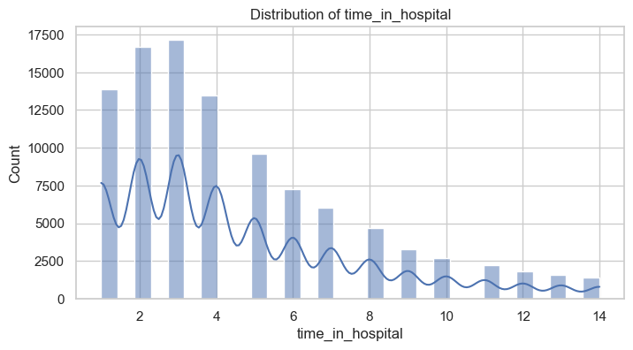

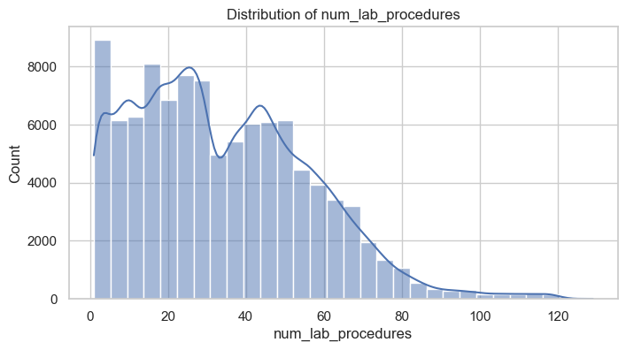

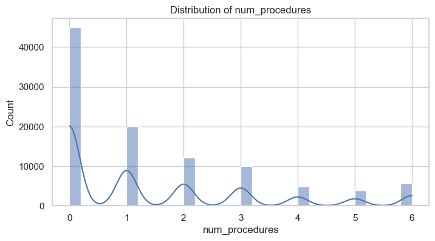

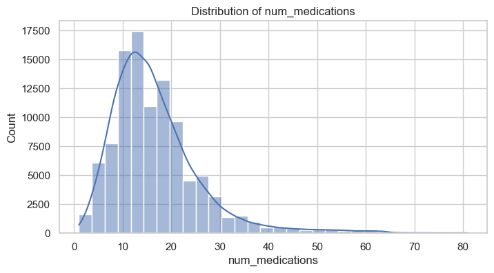

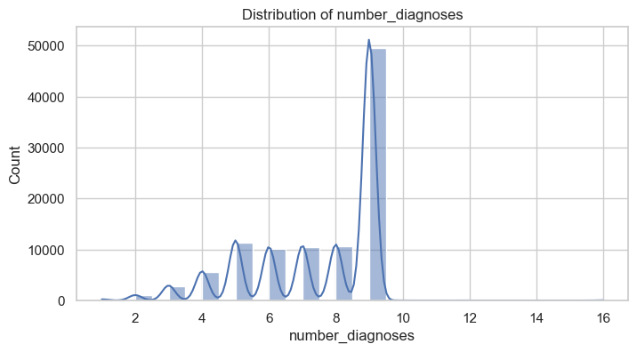

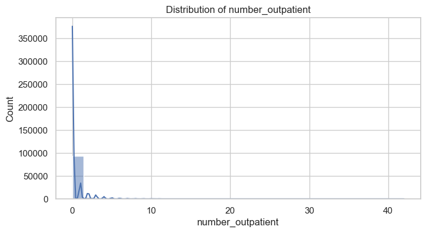

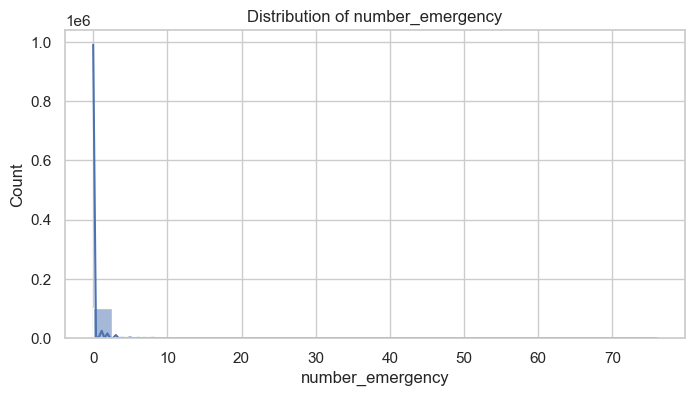

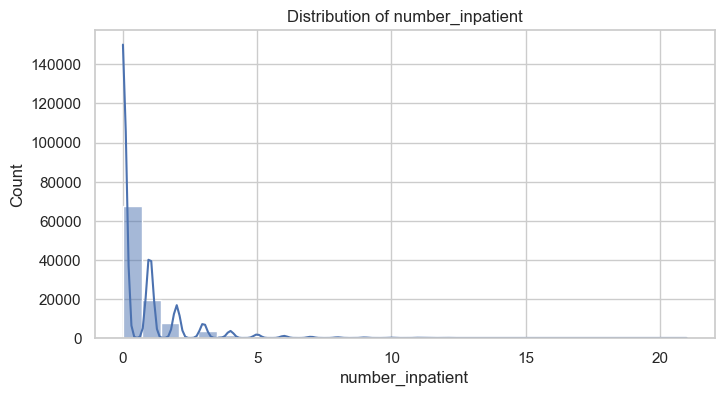

```python
numeric_cols = ['time_in_hospital', 'num_lab_procedures', 'num_procedures',
                'num_medications', 'number_diagnoses', 'number_outpatient',
                'number_emergency', 'number_inpatient']

for col in numeric_cols:
    plt.figure(figsize=(8,4))
    sns.histplot(readmission_df[col], bins=30, kde=True)
    plt.title(f'Distribution of {col}')
    plt.xlabel(col)
    plt.ylabel('Count')
    plt.show()
```

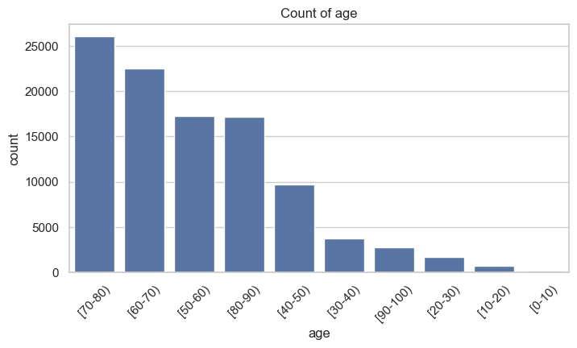

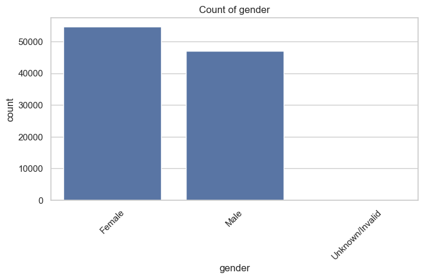

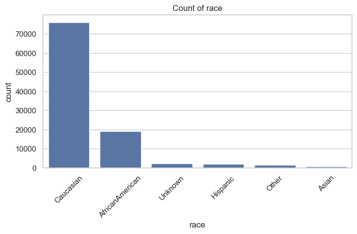

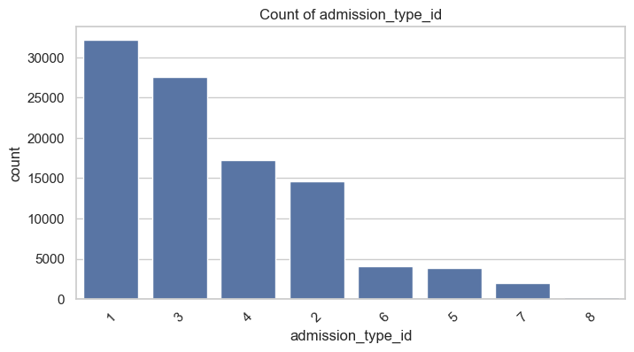

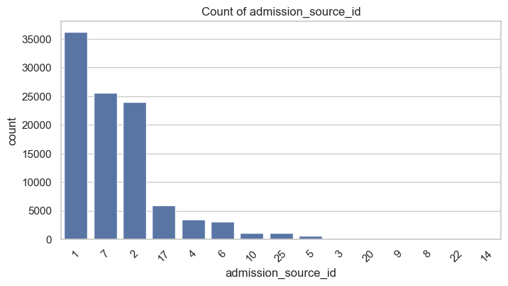

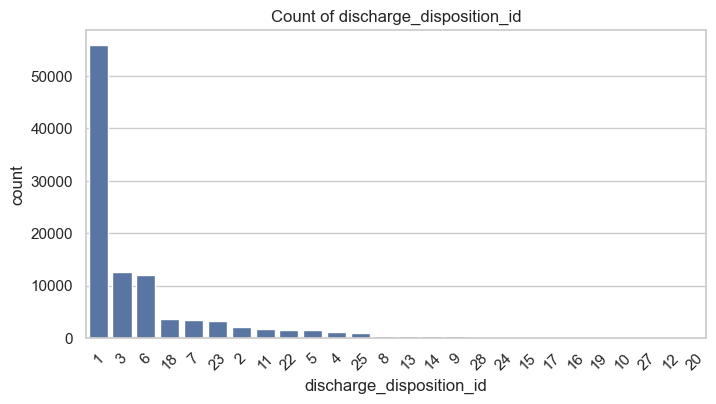

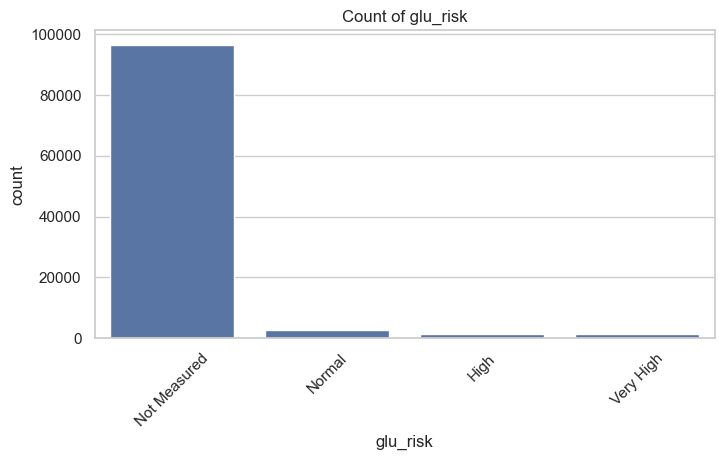

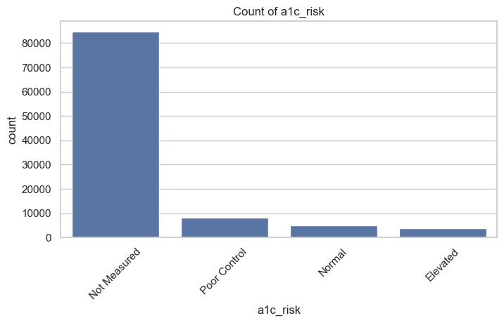

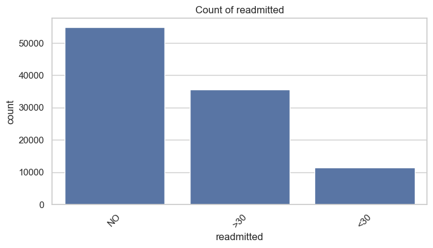

```python
categorical_cols = ['age', 'gender', 'race', 'admission_type_id',
                    'admission_source_id', 'discharge_disposition_id',
                    'glu_risk', 'a1c_risk', 'readmitted']

for col in categorical_cols:
    plt.figure(figsize=(8,4))
    sns.countplot(data=readmission_df, x=col, order=readmission_df[col].value_counts().index)
    plt.title(f'Count of {col}')
    plt.xticks(rotation=45)
    plt.show()
```

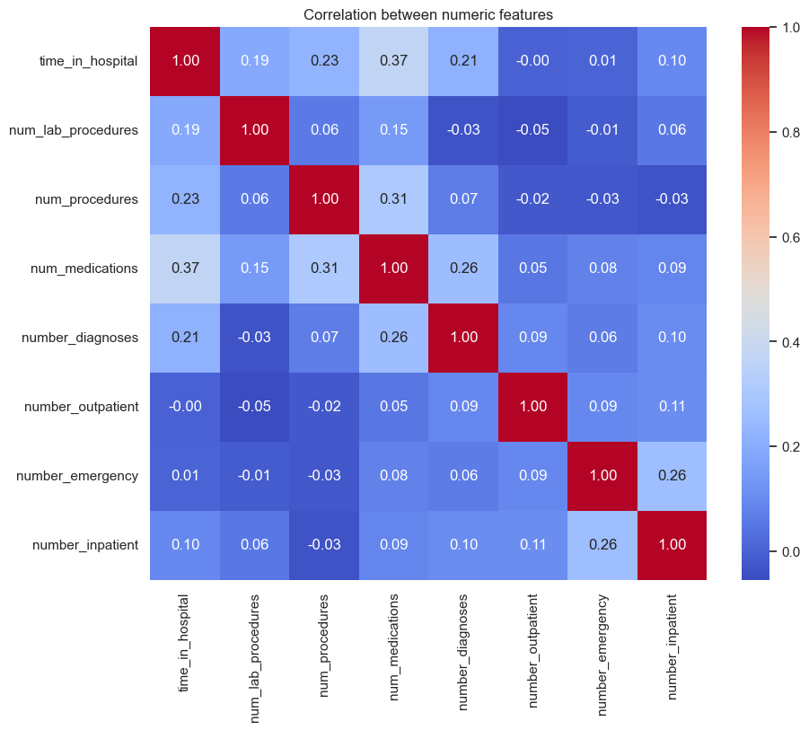

```python
plt.figure(figsize=(10,8))
sns.heatmap(readmission_df[numeric_cols].corr(), annot=True, fmt=".2f", cmap="coolwarm")
plt.title("Correlation between numeric features")
plt.show()
```

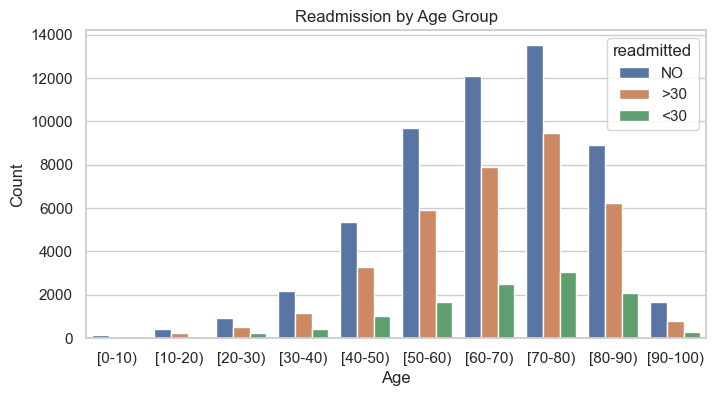

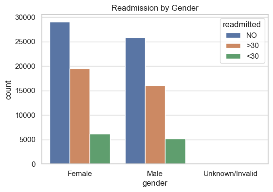

```python
# Example: Readmission by Age Group
plt.figure(figsize=(8,4))
sns.countplot(data=readmission_df, x='age', hue='readmitted')
plt.title('Readmission by Age Group')
plt.xlabel('Age')
plt.ylabel('Count')
plt.show()

# Example: Readmission by Gender
plt.figure(figsize=(6,4))
sns.countplot(data=readmission_df, x='gender', hue='readmitted')
plt.title('Readmission by Gender')
plt.show()
```

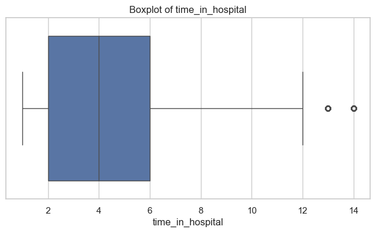

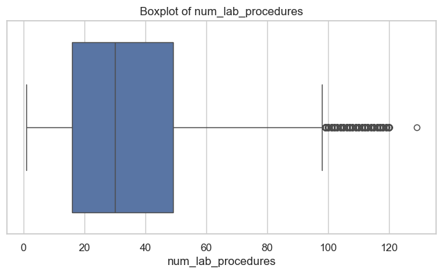

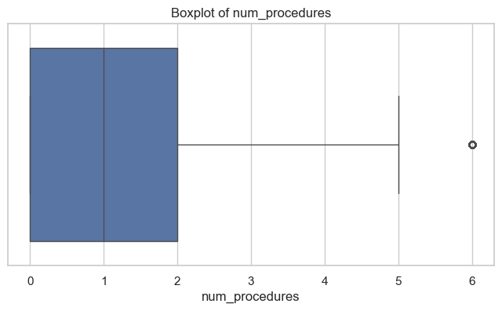

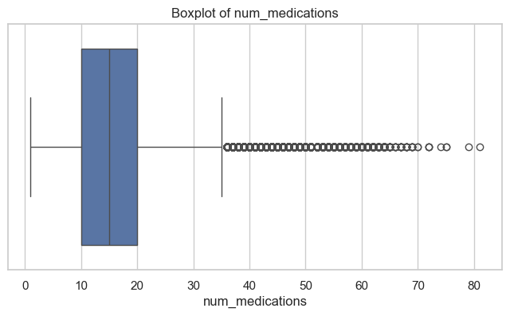

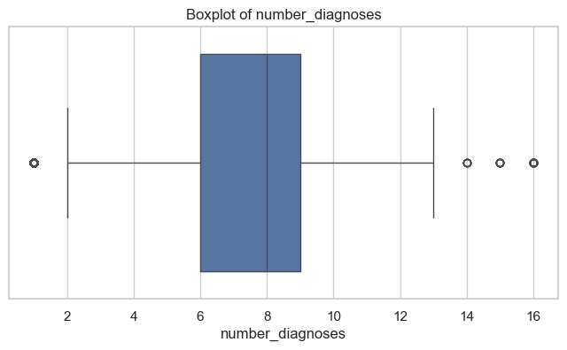

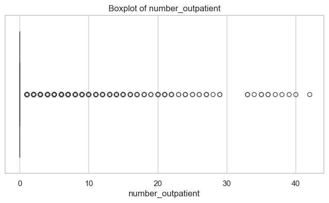

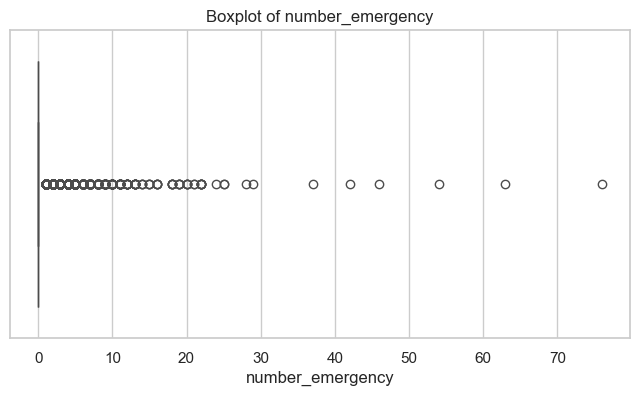

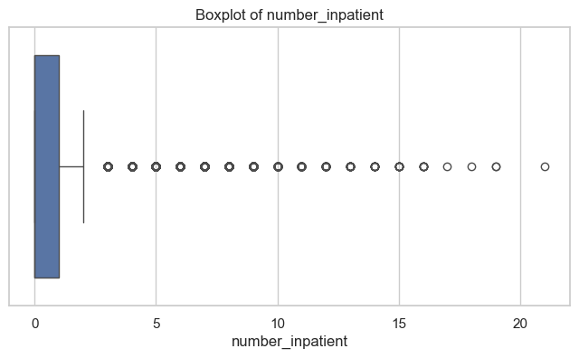

```python
for col in numeric_cols:
    plt.figure(figsize=(8,4))
    sns.boxplot(x=readmission_df[col])
    plt.title(f'Boxplot of {col}')
    plt.show()
```

```python
readmission_df.describe()
```

|  | time_in_hospital | num_lab_procedures | num_procedures | num_medications | number_diagnoses | number_outpatient | number_emergency | number_inpatient | readmitted_binary | glu_tested | a1c_tested | diabetes_med | med_change | gender_binary | index |
| --- | --- | --- | --- | --- | --- | --- | --- | --- | --- | --- | --- | --- | --- | --- | --- |
| count | 101766.000000 | 101766.000000 | 101766.000000 | 101766.000000 | 101766.000000 | 101766.000000 | 101766.000000 | 101766.000000 | 101766.000000 | 101766.000000 | 101766.000000 | 101766.000000 | 101766.0 | 101766.000000 | 101766.000000 |
| mean | 4.589696 | 34.047383 | 1.456577 | 16.560492 | 7.422607 | 0.369357 | 0.212232 | 0.635566 | 0.460881 | 0.052532 | 0.167227 | 0.714079 | 0.0 | 0.462384 | 50883.500000 |
| std | 3.160314 | 22.386944 | 1.792201 | 9.105980 | 1.933600 | 1.267265 | 0.917842 | 1.262863 | 0.498470 | 0.223099 | 0.373180 | 0.451854 | 0.0 | 0.498586 | 29377.458084 |
| min | 1.000000 | 1.000000 | 0.000000 | 1.000000 | 1.000000 | 0.000000 | 0.000000 | 0.000000 | 0.000000 | 0.000000 | 0.000000 | 0.000000 | 0.0 | 0.000000 | 1.000000 |
| 25% | 2.000000 | 16.000000 | 0.000000 | 10.000000 | 6.000000 | 0.000000 | 0.000000 | 0.000000 | 0.000000 | 0.000000 | 0.000000 | 0.000000 | 0.0 | 0.000000 | 25442.250000 |
| 50% | 4.000000 | 30.000000 | 1.000000 | 15.000000 | 8.000000 | 0.000000 | 0.000000 | 0.000000 | 0.000000 | 0.000000 | 0.000000 | 1.000000 | 0.0 | 0.000000 | 50883.500000 |
| 75% | 6.000000 | 49.000000 | 2.000000 | 20.000000 | 9.000000 | 0.000000 | 0.000000 | 1.000000 | 1.000000 | 0.000000 | 0.000000 | 1.000000 | 0.0 | 1.000000 | 76324.750000 |
| max | 14.000000 | 129.000000 | 6.000000 | 81.000000 | 16.000000 | 42.000000 | 76.000000 | 21.000000 | 1.000000 | 1.000000 | 1.000000 | 1.000000 | 0.0 | 1.000000 | 101766.000000 |